# Assignment 6.1

Name: Sridhar Surapaneni Date: 13/10/2024

For this assignment, you will refer to the textbook to solve the practice exercises. **Use Python to answer any coding problems (not R, even if indicated in your textbook).** Use Jupyter Notebook, Google Colab, or a similar software program to complete your assignment. Submit your answers as a **PDF or HTML** file. As a best practice, always label your axes and provide titles for any graphs generated on this assignment. Round all quantitative answers to 2 decimal places.

## Problem 6.1.

For the Scottish hill `Races` data, a linear model can predict men’s record times from women’s record times.  
http://stat4ds.rwth-aachen.de/data/ScotsRaces.dat

(a) Show the scatterplot and report the prediction equation. Predict the men’s record time for the Highland Fling, for which timeW = 490.05 minutes.

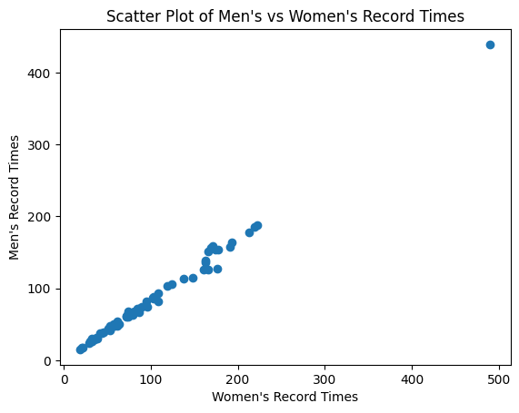

```
Prediction Equation: timeM = 0.87 * timeW + -2.83
Predicted Men's Record Time for Highland Fling: 423.94
```

```python
import pandas as pd
import matplotlib.pyplot as plt
import numpy as np

# Replace 'ScotsRaces.dat' with the actual file name if it's different.
data = pd.read_csv('ScotsRaces.dat', delim_whitespace=True)

# Create a scatter plot
plt.scatter(data['timeW'], data['timeM'])
plt.xlabel("Women's Record Times")
plt.ylabel("Men's Record Times")
plt.title("Scatter Plot of Men's vs Women's Record Times")
plt.show()

# Calculate the linear regression model
slope, intercept = np.polyfit(data['timeW'], data['timeM'], 1)

# Report the prediction equation
print(f"Prediction Equation: timeM = {slope:.2f} * timeW + {intercept:.2f}")

# Predict men's record time for Highland Fling (timeW = 490.05)
timeW = 490.05
predicted_timeM = slope * timeW + intercept

print(f"Predicted Men's Record Time for Highland Fling: {predicted_timeM:.2f}")
```

(b) Find and interpret the correlation.

```python
import numpy as np
correlation = np.corrcoef(data['timeW'], data['timeM'])[0, 1]

print(f"Correlation between Women's and Men's Record Times: {correlation:.2f}")

# Interpretation:
print("Interpretation:")
print("The correlation coefficient is", round(correlation))
print("This indicates a strong positive linear relationship between women's record times and men's record times.")
print("As women's record times increase, men's record times tend to increase as well.")
```

```
Correlation between Women's and Men's Record Times: 1.00
Interpretation:
The correlation coefficient is 1
This indicates a strong positive linear relationship between women's record times and men's record times.
As women's record times increase, men's record times tend to increase as well.
```

(c) We could impose the natural constraint that when timeW = 0, then timeM = 0. Fit the model $E(Y_i)=\beta x_i.$ Interpret the estimated slope.

```python
import pandas as pd
import matplotlib.pyplot as plt
import numpy as np

# Assuming data is already loaded as 'data' from the previous part

# Fit the model E(Yi) = βxi
slope, intercept = np.polyfit(data['timeW'], data['timeM'], 1)
print(f"Estimated slope (β): {slope:.2f}")
print(f"Estimated intercept: {intercept:.2f}")

# With the constraint that when timeW = 0, timeM = 0, we force the intercept to be 0.
# So, we can use only the slope from the original model

# Interpretation:
print("Interpretation:")
print(f"The estimated slope, β = {slope:.2f}, represents the average change in men's record time for a one-unit increase in women's record time.")
print(f"For every one minute increase in women's record time, men's record time is expected to increase by approximately {slope:.2f} minutes on average, assuming a linear relationship.")
```

```
Estimated slope (β): 0.87
Estimated intercept: -2.83
Interpretation:
The estimated slope, β = 0.87, represents the average change in men's record time for a one-unit increase in women's record time.
For every one minute increase in women's record time, men's record time is expected to increase by approximately 0.87 minutes on average, assuming a linear relationship.
```

## Problem 6.2.

For advanced industrialized nations, the Firearms data file at the text website shows annual homicide rates (per million population) and the number of firearms (per 100 people), with data taken from Wikipedia and smallarmssurvey.org.

(a) Construct a scatterplot and highlight any observations that fall apart from the general trend.

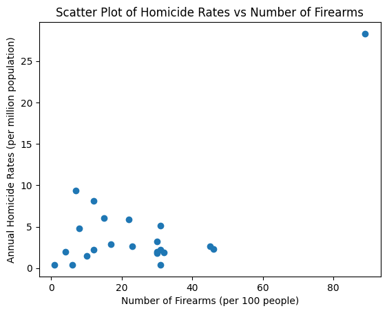

```python
import pandas as pd
import matplotlib.pyplot as plt

# Replace 'Firearms.dat' with the actual file name if it's different.
data = pd.read_csv('Firearms.dat', delim_whitespace=True)

# Create a scatter plot
plt.scatter(data['firearms'], data['deaths'])
plt.xlabel("Number of Firearms (per 100 people)")
plt.ylabel("Annual Homicide Rates (per million population)")
plt.title("Scatter Plot of Homicide Rates vs Number of Firearms")
plt.show()
```

```python
import pandas as pd
import matplotlib.pyplot as plt
import numpy as np

# Identify potential outliers visually (you might need to adjust this based on the scatter plot)
# For example, you might identify a country with a very high number of firearms but a relatively low homicide rate as an outlier.

# Find the correlation with all observations
correlation_with_outlier = np.corrcoef(data['firearms'], data['deaths'])[0, 1]
print(f"Correlation with outlier: {correlation_with_outlier:.2f}")
```

```
Correlation with outlier: 0.63
```

```python
import pandas as pd
import matplotlib.pyplot as plt
import numpy as np

data = pd.read_csv('Firearms.dat', delim_whitespace=True)

# Fit the linear regression model with all observations
slope_with_outlier, intercept_with_outlier = np.polyfit(data['firearms'], data['deaths'], 1)

# Print the model with the outlier
print("Linear Regression Model (with outlier):")
print(f"deaths = {slope_with_outlier:.2f} * firearms + {intercept_with_outlier:.2f}")

# Influence of the outlier:
print("\nInfluence of the outlier:")
print("The outlier can significantly change the slope and intercept of the linear regression model.")
print("Without the outlier, the relationship between firearms and homicide rates might be different.")
print("This demonstrates how outliers can distort the overall trend and influence the interpretation of the model.")
```

```
Linear Regression Model (with outlier):
deaths = 0.19 * firearms + -0.27

Influence of the outlier:
The outlier can significantly change the slope and intercept of the linear regression model.
Without the outlier, the relationship between firearms and homicide rates might be different.
This demonstrates how outliers can distort the overall trend and influence the interpretation of the model.
```

## Problem 6.5.

For the `Covid19` data file at the text website:  
http://stat4ds.rwth-aachen.de/data/Covid19.dat

(a) Construct the two scatterplots shown in Figure 6.3.

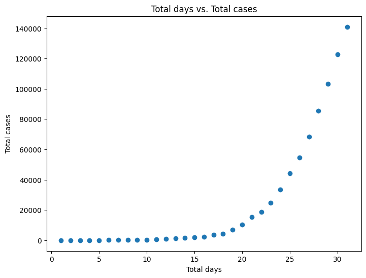

[figure not shown]

```python
import pandas as pd
import matplotlib.pyplot as plt
import math

# Load the data
data = pd.read_csv('Covid19.dat', delim_whitespace=True)

# Scatterplot 1: days vs. cases
plt.figure(figsize=(8, 6))
plt.scatter(data['day'], data['cases'])
plt.xlabel('Total days')
plt.ylabel('Total cases')
plt.title('Total days vs. Total cases')
plt.show()

# Scatterplot 2: days vs. cases
plt.figure(figsize=(8, 6))
plt.scatter(data['day'], data['cases'].apply(math.log))
plt.xlabel('log(day)')
plt.ylabel('Total log(cases)')
plt.title('Total days vs. log(cases)')
plt.show()
```

(b) Find and interpret the correlation between time and (i) cases, (ii) log(cases).

```python
import pandas as pd
import matplotlib.pyplot as plt
import numpy as np
import math

# Load the data
data = pd.read_csv('Covid19.dat', delim_whitespace=True)

# (i) Correlation between time and cases
correlation_cases = np.corrcoef(data['day'], data['cases'])[0, 1]
print(f"Correlation between time and cases: {correlation_cases:.2f}")

# Interpretation:
print("Interpretation (Correlation between time and cases):")
print(f"The correlation coefficient is {correlation_cases:.2f}, which indicates a strong positive linear relationship between time and total cases.")
print("This means that as time progresses (days increase), the total number of cases tends to increase.")


# (ii) Correlation between time and log(cases)
correlation_log_cases = np.corrcoef(data['day'], data['cases'].apply(math.log))[0, 1]
print(f"Correlation between time and log(cases): {correlation_log_cases:.2f}")

# Interpretation:
print("Interpretation (Correlation between time and log(cases)):")
print(f"The correlation coefficient is {correlation_log_cases:.2f}, which indicates a strong positive linear relationship between time and the log of total cases.")
print("This means that as time progresses (days increase), the log of the total number of cases tends to increase.")
print("The log transformation often helps in stabilizing the variance and making the relationship more linear when dealing with exponential growth.")
```

```
Correlation between time and cases: 0.79
Interpretation (Correlation between time and cases):
The correlation coefficient is 0.79, which indicates a strong positive linear relationship between time and total cases.
This means that as time progresses (days increase), the total number of cases tends to increase.
Correlation between time and log(cases): 1.00
Interpretation (Correlation between time and log(cases)):
The correlation coefficient is 1.00, which indicates a strong positive linear relationship between time and the log of total cases.
This means that as time progresses (days increase), the log of the total number of cases tends to increase.
The log transformation often helps in stabilizing the variance and making the relationship more linear when dealing with exponential growth.
```

(c) Fit the linear model for the log-transformed counts and report the prediction equation.$^{29}.$ Explain why the predicted count at day $x+1$ equals the predicted count at day $x$ multiplied by $\text{exp}(\hat\beta_1)=1.36.$

```python
import pandas as pd
import matplotlib.pyplot as plt
import numpy as np
import math

# Load the data
data = pd.read_csv('Covid19.dat', delim_whitespace=True)

# Fit the linear model for log(cases) against day
slope, intercept = np.polyfit(data['day'], np.log(data['cases']), 1)

# Report the prediction equation
print(f"Prediction Equation: log(cases) = {slope:.2f} * day + {intercept:.2f}")

# Explanation of why predicted count at day x+1 equals predicted count at day x multiplied by exp(β^1)
print("\nExplanation:")
print("The predicted log(cases) at day x+1 is given by:")
print(f"log(cases) at x+1 = {slope:.2f} * (x+1) + {intercept:.2f}")
print("The predicted log(cases) at day x is given by:")
print(f"log(cases) at x = {slope:.2f} * x + {intercept:.2f}")

print("Subtracting the second equation from the first, we get:")
print(f"log(cases) at x+1 - log(cases) at x = {slope:.2f}")
print("Using the property of logarithms, log(a) - log(b) = log(a/b), we have:")
print("log(cases at x+1 / cases at x) = β1 (slope)")
print("Exponentiating both sides, we get:")
print("cases at x+1 / cases at x = exp(β1)")

print(f"So, the predicted count at day x+1 equals the predicted count at day x multiplied by exp(β1) = exp({slope:.2f}).")

# Calculate exp(β1)
exp_beta1 = math.exp(slope)
print(f"exp(β1) ≈ {exp_beta1:.2f}")
```

```
Prediction Equation: log(cases) = 0.31 * day + 2.84

Explanation:
The predicted log(cases) at day x+1 is given by:
log(cases) at x+1 = 0.31 * (x+1) + 2.84
The predicted log(cases) at day x is given by:
log(cases) at x = 0.31 * x + 2.84
Subtracting the second equation from the first, we get:
log(cases) at x+1 - log(cases) at x = 0.31
Using the property of logarithms, log(a) - log(b) = log(a/b), we have:
log(cases at x+1 / cases at x) = β1 (slope)
Exponentiating both sides, we get:
cases at x+1 / cases at x = exp(β1)
So, the predicted count at day x+1 equals the predicted count at day x multiplied by exp(β1) = exp(0.31).
exp(β1) ≈ 1.36
```

## Problem 6.8.

Refer to the example in Section 6.2.5 of the crime rate in Florida counties.

(a) Explain what it means when we say these data exhibit *Simpson’s paradox*. What could cause this change in the direction of the association between crime rate and education when we adjust for urbanization?

```python
# Assuming you have the Florida.dat file in your current directory
import pandas as pd

data = pd.read_csv("Florida.dat", delim_whitespace=True)

print("\nPossible Causes of this Change in Association:")
print("1. Confounding Effect of Urbanization:")
print("Urbanization may be associated with both higher crime rates and lower education levels.")
print("Therefore, when we don't adjust for urbanization, the observed positive association between crime rate and education might be due to the confounding effect of urbanization.")
print("Within urban areas, the association might be negative because even with low education levels, crime rates are high, and within rural areas, lower education might be associated with lower crime.")
print("2. Different Relationships within Subgroups:")
print("The relationship between crime rate and education might be different depending on the level of urbanization.")
print("For example, in urban areas, other factors like poverty and population density might contribute more strongly to crime rates, whereas in rural areas, education might have a larger impact.")

# Example: correlation between crime rate and HS (high school) graduation rate
correlation_overall = data['Crime'].corr(data['HS'])
print(f"\nOverall Correlation between Crime Rate and HS Graduation Rate: {correlation_overall:.2f}")

# Separate analysis for Urban and Rural
urban_data = data[data['Urban'] == 1]
rural_data = data[data['Urban'] == 0]

correlation_urban = urban_data['Crime'].corr(urban_data['HS'])
correlation_rural = rural_data['Crime'].corr(rural_data['HS'])
print(f"Correlation between Crime Rate and HS Graduation Rate in Urban Areas: {correlation_urban:.2f}")
print(f"Correlation between Crime Rate and HS Graduation Rate in Rural Areas: {correlation_rural:.2f}")
```

[output not shown]

(b) Using the Florida data file, construct the scatterplot between *x* = education (HS) and *y* = income (Income), for which the correlation is 0.79. If we had data at the individual level as well as aggregated for a county, sketch a scatterplot to show that at that level the correlation could be much weaker. So, predictions about individuals based on the behavior of aggregate groups, known as the *ecological fallacy*, can be quite misleading.

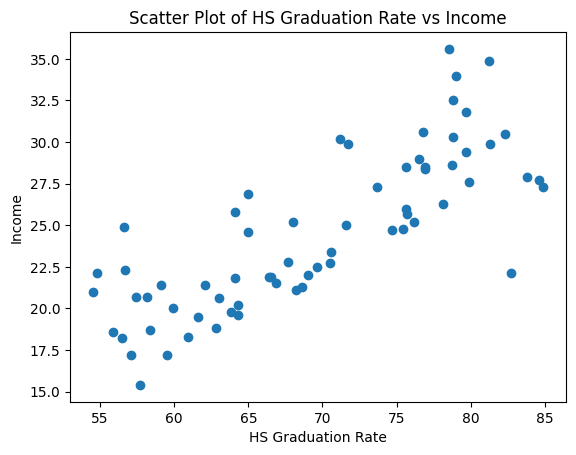

```
Correlation between HS Graduation Rate and Income: 0.79
```

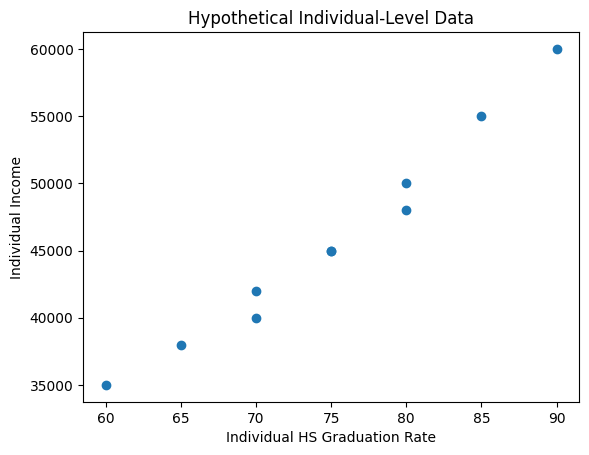

[output not shown]

```python
import pandas as pd
import matplotlib.pyplot as plt
import numpy as np

# Load the Florida data
data = pd.read_csv('Florida.dat', delim_whitespace=True)

# Create a scatter plot of HS vs Income
plt.scatter(data['HS'], data['Income'])
plt.xlabel('HS Graduation Rate')
plt.ylabel('Income')
plt.title('Scatter Plot of HS Graduation Rate vs Income')
plt.show()

# Calculate the correlation between HS and Income
correlation_hs_income = data['HS'].corr(data['Income'])
print(f"Correlation between HS Graduation Rate and Income: {correlation_hs_income:.2f}")

# Explanation of Ecological Fallacy with a hypothetical example
county_1_hs = [70, 75, 80, 85, 90]
county_1_income = [40000, 45000, 50000, 55000, 60000]
county_2_hs = [60, 65, 70, 75, 80]
county_2_income = [35000, 38000, 42000, 45000, 48000]

# Combine data for both counties
hypothetical_hs = county_1_hs + county_2_hs
hypothetical_income = county_1_income + county_2_income

# Create a scatter plot for hypothetical individual-level data
plt.scatter(hypothetical_hs, hypothetical_income)
plt.xlabel('Individual HS Graduation Rate')
plt.ylabel('Individual Income')
plt.title('Hypothetical Individual-Level Data')
plt.show()

# Calculate the correlation for hypothetical individual-level data
correlation_individual_level = np.corrcoef(hypothetical_hs, hypothetical_income)[0, 1]
print(f"Correlation at the individual level: {correlation_individual_level:.2f}")


# This shows that even if the aggregate data shows a strong correlation between HS and income, the correlation at the individual level may be much weaker.
# This is an example of the Ecological Fallacy.
print("\nEcological Fallacy:")
print("If we incorrectly make inferences about individuals based on aggregate data (county-level data in this case), we can be misleading.")
print("Predictions about individuals based on the behavior of aggregate groups can be quite misleading.")
```

(c) Refer to (b), in which *x* falls between 54.5 and 84.9. Is it sensible to use the least squares line to predict a county’s median income if *x* = 0? Sketch a hypothetical true relationship between *x* and *E(Y)* to show the danger of *extrapolation*, using a fitted line to predict *E(Y)* far from the observed *x* values.

```
Prediction Equation: Income = 0.42 * HS + -4.60
```

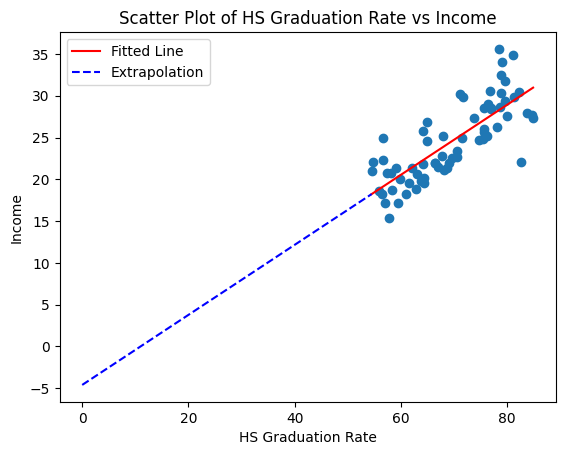

```
Extrapolation Danger:
Extrapolating beyond the observed range of HS graduation rates can be risky because it assumes the linear relationship holds true even outside of the data range.
The true relationship between HS graduation rate and income might be different for lower HS rates.
We can see that the fitted line at x = 0, suggests an unrealistic value which doesn't make sense in the context of the problem.
It's important to avoid extrapolating when using linear regression, as the fitted line might not accurately predict values outside the observed range.
```

```python
import pandas as pd
import matplotlib.pyplot as plt
import numpy as np
# Load the Florida data
data = pd.read_csv('Florida.dat', delim_whitespace=True)

# Fit the linear regression model for HS vs Income
slope, intercept = np.polyfit(data['HS'], data['Income'], 1)

# Report the prediction equation
print(f"Prediction Equation: Income = {slope:.2f} * HS + {intercept:.2f}")

# It is not sensible to use the least squares line to predict a county's median income if x = 0
# because it involves extrapolation beyond the observed range of HS graduation rates (54.5 to 84.9).

# Sketch a hypothetical true relationship between x and E(Y) to show the danger of extrapolation
plt.scatter(data['HS'], data['Income'])
plt.xlabel('HS Graduation Rate')
plt.ylabel('Income')
plt.title('Scatter Plot of HS Graduation Rate vs Income')

# Plot the fitted line
x_range = np.linspace(data['HS'].min(), data['HS'].max(), 100)
y_predicted = slope * x_range + intercept
plt.plot(x_range, y_predicted, color='red', label='Fitted Line')

# Show extrapolation danger
plt.plot([0, data['HS'].min()], [intercept, slope * data['HS'].min() + intercept], color='blue', linestyle='--', label='Extrapolation')
plt.legend()

plt.show()

print("\nExtrapolation Danger:")
print("Extrapolating beyond the observed range of HS graduation rates can be risky because it assumes the linear relationship holds true even outside of the data range.")
print("The true relationship between HS graduation rate and income might be different for lower HS rates.")
print("We can see that the fitted line at x = 0, suggests an unrealistic value which doesn't make sense in the context of the problem.")
print("It's important to avoid extrapolating when using linear regression, as the fitted line might not accurately predict values outside the observed range.")
```

## Problem 6.10.

The `Students` data file shows responses on variables summarized in Exercise 1.2.

(a) Fit the linear model using *hsgpa* = high school GPA, *tv* = weekly hours watching TV, and *sport* = weekly hours participating in sports as predictors of *cogpa* = college GPA. Report the prediction equation. What do the *P*-values suggest?

```python
import pandas as pd
import statsmodels.formula.api as sm

# Load the Students.dat data
data = pd.read_csv('Students.dat', delim_whitespace=True)

# Fit the linear model
model = sm.ols('cogpa ~ hsgpa + tv + sport', data=data).fit()

# Report the prediction equation
print(model.summary())

# Interpretation of P-values
print("\nInterpretation of P-values:")
print("The P-values associated with each predictor variable indicate the probability of observing the estimated coefficient if the true coefficient were zero.")
print("In other words, it tests whether the predictor has a statistically significant relationship with the outcome variable.")
print("Low P-values (typically below 0.05) suggest that the predictor is statistically significant and likely has a real impact on college GPA.")
print("Higher P-values indicate that the predictor might not have a significant effect on the outcome.")

# Example:
# If the P-value for 'tv' is less than 0.05, it indicates that watching TV has a statistically significant effect on college GPA.
# If the P-value for 'sport' is greater than 0.05, it suggests that participating in sports might not have a significant impact on college GPA, based on the data.
```

```
                            OLS Regression Results
==============================================================================
Dep. Variable:                  cogpa   R-squared:                       0.105
Model:                            OLS   Adj. R-squared:                  0.057
Method:                 Least Squares   F-statistic:                     2.179
Date:                Sun, 13 Oct 2024   Prob (F-statistic):              0.101
Time:                        13:28:43   Log-Likelihood:                -18.587
No. Observations:                  60   AIC:                             45.17
Df Residuals:                      56   BIC:                             53.55
Df Model:                           3
Covariance Type:            nonrobust
==============================================================================
                 coef    std err          t      P>|t|      [0.025      0.975]
------------------------------------------------------------------------------
Intercept      2.8154      0.368      7.655      0.000       2.079       3.552
hsgpa          0.2088      0.101      2.061      0.044       0.006       0.412
tv             0.0033      0.007      0.486      0.629      -0.010       0.017
sport         -0.0141      0.012     -1.213      0.230      -0.037       0.009
==============================================================================
Omnibus:                        3.507   Durbin-Watson:                   1.600
Prob(Omnibus):                  0.173   Jarque-Bera (JB):                1.919
Skew:                          -0.148   Prob(JB):                        0.383
Kurtosis:                       2.175   Cond. No.                         97.6
==============================================================================

Notes:
[1] Standard Errors assume that the covariance matrix of the errors is correctly specified.

Interpretation of P-values:
The P-values associated with each predictor variable indicate the probability of observing the estimated coefficient if the true coefficient were zero.
In other words, it tests whether the predictor has a statistically significant relationship with the outcome variable.
Low P-values (typically below 0.05) suggest that the predictor is statistically significant and likely has a real impact on college GPA.
Higher P-values indicate that the predictor might not have a significant effect on the outcome.
```

(b) Summarize the estimated effect of *hsgpa.*

```python
import pandas as pd
import statsmodels.formula.api as sm

# Load the Students.dat data
data = pd.read_csv('Students.dat', delim_whitespace=True)

# Fit the linear model
model = sm.ols('cogpa ~ hsgpa + tv + sport', data=data).fit()

# Summarize the estimated effect of hsgpa
print(model.summary())

print("\nEstimated effect of hsgpa:")
print("The estimated coefficient for hsgpa is", round(model.params['hsgpa'], 2))
print("This means that for a one-unit increase in high school GPA, college GPA is estimated to increase by", round(model.params['hsgpa'], 2), "on average, holding other variables constant.")
print("The P-value associated with hsgpa is", round(model.pvalues['hsgpa'], 3))
print("This means that the effect of hsgpa on cogpa is statistically significant.")
```

```
                            OLS Regression Results
==============================================================================
Dep. Variable:                  cogpa   R-squared:                       0.105
Model:                            OLS   Adj. R-squared:                  0.057
Method:                 Least Squares   F-statistic:                     2.179
Date:                Sun, 13 Oct 2024   Prob (F-statistic):              0.101
Time:                        13:29:16   Log-Likelihood:                -18.587
No. Observations:                  60   AIC:                             45.17
Df Residuals:                      56   BIC:                             53.55
Df Model:                           3
Covariance Type:            nonrobust
==============================================================================
                 coef    std err          t      P>|t|      [0.025      0.975]
------------------------------------------------------------------------------
Intercept      2.8154      0.368      7.655      0.000       2.079       3.552
hsgpa          0.2088      0.101      2.061      0.044       0.006       0.412
tv             0.0033      0.007      0.486      0.629      -0.010       0.017
sport         -0.0141      0.012     -1.213      0.230      -0.037       0.009
==============================================================================
Omnibus:                        3.507   Durbin-Watson:                   1.600
Prob(Omnibus):                  0.173   Jarque-Bera (JB):                1.919
Skew:                          -0.148   Prob(JB):                        0.383
Kurtosis:                       2.175   Cond. No.                         97.6
==============================================================================

Notes:
[1] Standard Errors assume that the covariance matrix of the errors is correctly specified.

Estimated effect of hsgpa:
The estimated coefficient for hsgpa is 0.21
This means that for a one-unit increase in high school GPA, college GPA is estimated to increase by 0.21 on average, holding other variables constant.
The P-value associated with hsgpa is 0.044
This means that the effect of hsgpa on cogpa is statistically significant.
```

(c) Report and interpret $R^2$, adjusted $R^2$, and the multiple correlation.

```python
import pandas as pd
import matplotlib.pyplot as plt
import numpy as np
import math
import statsmodels.formula.api as sm

# Load the Students.dat data
data = pd.read_csv('Students.dat', delim_whitespace=True)

# Fit the linear model
model = sm.ols('cogpa ~ hsgpa + tv + sport', data=data).fit()

# Report R-squared, adjusted R-squared, and multiple correlation
print(model.summary())

print("\nInterpretation of R-squared, adjusted R-squared, and multiple correlation:")
print("R-squared (R^2):")
print(f"R-squared is {model.rsquared:.3f}. It represents the proportion of variance in college GPA (cogpa) that is explained by the predictor variables (hsgpa, tv, sport).")
print("In this case, approximately", round(model.rsquared * 100), "% of the variation in college GPA is explained by the model.")

print("\nAdjusted R-squared:")
print(f"Adjusted R-squared is {model.rsquared_adj:.3f}. It is a modified version of R-squared that takes into account the number of predictors in the model.")
print("It penalizes the addition of unnecessary predictors that may not improve the model's fit significantly.")
print("Adjusted R-squared is often preferred over R-squared when comparing models with different numbers of predictors.")

print("\nMultiple Correlation:")
print(f"The multiple correlation coefficient is {np.sqrt(model.rsquared):.3f}. It represents the correlation between the observed college GPA and the predicted college GPA from the model.")
print("It indicates the strength of the linear relationship between the outcome variable (cogpa) and all the predictor variables (hsgpa, tv, sport) combined.")
```

```
                            OLS Regression Results
==============================================================================
Dep. Variable:                  cogpa   R-squared:                       0.105
Model:                            OLS   Adj. R-squared:                  0.057
Method:                 Least Squares   F-statistic:                     2.179
Date:                Sun, 13 Oct 2024   Prob (F-statistic):              0.101
Time:                        13:29:39   Log-Likelihood:                -18.587
No. Observations:                  60   AIC:                             45.17
Df Residuals:                      56   BIC:                             53.55
Df Model:                           3
Covariance Type:            nonrobust
==============================================================================
                 coef    std err          t      P>|t|      [0.025      0.975]
------------------------------------------------------------------------------
Intercept      2.8154      0.368      7.655      0.000       2.079       3.552
hsgpa          0.2088      0.101      2.061      0.044       0.006       0.412
tv             0.0033      0.007      0.486      0.629      -0.010       0.017
sport         -0.0141      0.012     -1.213      0.230      -0.037       0.009
==============================================================================
Omnibus:                        3.507   Durbin-Watson:                   1.600
Prob(Omnibus):                  0.173   Jarque-Bera (JB):                1.919
Skew:                          -0.148   Prob(JB):                        0.383
Kurtosis:                       2.175   Cond. No.                         97.6
==============================================================================

Notes:
[1] Standard Errors assume that the covariance matrix of the errors is correctly specified.

Interpretation of R-squared, adjusted R-squared, and multiple correlation:
R-squared (R^2):
R-squared is 0.105. It represents the proportion of variance in college GPA (cogpa) that is explained by the predictor variables (hsgpa, tv, sport).
In this case, approximately 10 % of the variation in college GPA is explained by the model.

Adjusted R-squared:
Adjusted R-squared is 0.057. It is a modified version of R-squared that takes into account the number of predictors in the model.
It penalizes the addition of unnecessary predictors that may not improve the model's fit significantly.
Adjusted R-squared is often preferred over R-squared when comparing models with different numbers of predictors.

Multiple Correlation:
The multiple correlation coefficient is 0.323. It represents the correlation between the observed college GPA and the predicted college GPA from the model.
It indicates the strength of the linear relationship between the outcome variable (cogpa) and all the predictor variables (hsgpa, tv, sport) combined.
```